# Proposal Project EndTerm - PHÂN TÍCH VÀ DỰ ĐOÁN SUY TIM

NHOM-10

2022-10-25

# Thành viên:

- 20133033 - Bùi Tấn Đạt
- 20133075 - Võ Hoàng Nguyên
- 20133108 - Trần Tuyên Trường
- 20133008 - Hoàng Uyên

# 1. Giới thiệu

- Bệnh tim mạch (CVD) là nguyên nhân gây tử vong số 1 trên toàn cầu, cướp đi sinh mạng của khoảng 17,9 triệu người mỗi năm, chiếm 31% tổng số ca tử vong trên toàn thế giới. Bốn trong số 5CVD tử vong là do đau tim và đột quỵ, và một phần ba số ca tử vong này xảy ra sớm ở những người dưới 70 tuổi. Suy tim là một sự kiện phổ biến do CVD gây ra và bộ dữ liệu này có thể được sử dụng để dự đoán bệnh tim có thể xảy ra.
- Những người mắc bệnh tim mạch hoặc những người có nguy cơ tim mạch cao (do sự hiện diện của một hoặc nhiều yếu tố nguy cơ như tăng huyết áp, tiểu đường, tăng lipid máu hoặc bệnh đã được thiết lập) cần được phát hiện và quản lý sớm, trong đó mô hình học máy có thể giúp ích rất nhiều.

## Câu hỏi nghiên cứu:

  1. Lượng Cholestorol cao hay thấp ảnh hưởng như thế nào đến khả năng mắc bệnh suy tim?
  2. Giới tính có ảnh hưởng đến khả năng mắc bệnh suy tim cao hay thấp không?
  3. Liệu rằng người lớn tuổi có khả năng mắc bệnh suy tim cao hơn người trẻ hay không?
  4. Trong các yếu tố ở dữ liệu, đâu là những yếu tố chính dẫn đến nguy cơ mắc bệnh tim suy tim cao hơn?

## Dữ liệu của nhóm:

  - Dữ liệu cho cho đồ án được lấy từ website ([Heart Failure Prediction Dataset | Kaggle](https://www.kaggle.com/datasets/fedesoriano/heart-failure-prediction?resource=download)). Gồm 1 tập dữ liệu ở dạng (.csv) /heart.csv.
  - Tập dữ liệu này được tạo bằng cách kết hợp các tập dữ liệu khác nhau đã có sẵn một cách độc lập nhưng chưa được kết hợp trước đó. Trong bộ dữ liệu này, 5 bộ dữ liệu về tim được kết hợp trên 11 đặc điểm chung khiến nó trở thành bộ dữ liệu về bệnh tim lớn nhất có sẵn cho mục đích nghiên cứu cho đến nay. Năm bộ dữ liệu được sử dụng để quản lý nó là:
    - Cleveland: 303 quan sát
    - Hungarian: 294 quan sát
    - Switzerland: 123 quan sát
    - Long Beach VA: 200 quan sát
    - Stalog (Heart) Data Set: 270 quan sát
    - Total: 1190 quan sát
    - Duplicated: 272 quan sát
    - Tập dữ liệu cuối cùng: 918 quan sát
    - Mọi bộ dữ liệu được sử dụng có thể được tìm thấy trong Chỉ mục bộ dữ liệu bệnh tim từ Kho lưu trữ Máy học UCI trên liên kết sau: https://archive.ics.uci.edu/ml/machine-learning-databases/heart-disease/
  - Biến phân loại (định tính): Sex, ChestPainType, FastingBS, RestingECG, ExerciseAngina, ST_Slope, HeartDisease
  - Biến số (định lượng): Age, RestingBP, Cholesterol, MaxHR, Oldpeak

# 2. Dữ liệu

- Thông tin về bộ dữ liệu mà nhóm phân tích

  Bộ dữ liệu gồm: 12 cột và 918 dòng. Trong đó:

  - Age: Tuổi của bệnh nhân

  - Sex: giới tính của bệnh nhân [M: Nam, F: Nữ]

  - ChestPainType: loại đau ngực [TA: Đau thắt ngực điển hình, ATA: Đau thắt ngực không điển hình, NAP: Đau thắt ngực không, ASY: Không có triệu chứng]

  - RestingBP: resting blood pressure - huyết áp khi nghỉ ngơi [mm Hg]

  - Cholesterol: lượng cholesterol [mg/dL]

  - FastingBS: fasting blood sugar - đường huyết lúc đói [1: nếu FastingBS \> 120 mg/dL, 0: nếu FastingBS \<= 120 mg/dL]

  - RestingECG: kết quả điện tâm đồ lúc nghỉ [Normal: Bình thường, ST: có bất thường sóng ST-T (đảo ngược sóng T và / hoặc ST chênh lên hoặc giảm \> 0,05 mV), LVH: cho thấy phì đại thất trái có thể hoặc xác định theo tiêu chuẩn của Estes]

  - MaxHR: nhịp tim tối đa đạt được [Giá trị số từ 60 đến 202]

  - ExerciseAngina: đau thắt ngực do tập thể dục [Y: Có, N: Không]

  - Oldpeak: oldpeak = ST [Giá trị số được đo bằng độ trầm cảm]

  - ST_Slope: độ dốc của bài tập đỉnh cao Đoạn ST [Up: dốc lên, Flat: bằng phẳng, Down: dốc xuống]

  - HeartDisease: Bị bệnh tim [1: Có, 0: Không]

```r
library("knitr")
library(tidyverse)
```

```r
library(dplyr)
library(ggplot2)
library(gapminder)
```

** Đọc dữ tập dữ liệu: xuất theo kiểu string <str> để đọc được số dòng là 918 theo 12 biến.

```r
datadisease <- read.csv("./data/heart.csv")
str(datadisease)
```

```
## 'data.frame':    918 obs. of  12 variables:
##  $ Age           : int  40 49 37 48 54 39 45 54 37 48 ...
##  $ Sex           : chr  "M" "F" "M" "F" ...
##  $ ChestPainType : chr  "ATA" "NAP" "ATA" "ASY" ...
##  $ RestingBP     : int  140 160 130 138 150 120 130 110 140 120 ...
##  $ Cholesterol   : int  289 180 283 214 195 339 237 208 207 284 ...
##  $ FastingBS     : int  0 0 0 0 0 0 0 0 0 0 ...
##  $ RestingECG    : chr  "Normal" "Normal" "ST" "Normal" ...
##  $ MaxHR         : int  172 156 98 108 122 170 170 142 130 120 ...
##  $ ExerciseAngina: chr  "N" "N" "N" "Y" ...
##  $ Oldpeak       : num  0 1 0 1.5 0 0 0 0 1.5 0 ...
##  $ ST_Slope      : chr  "Up" "Flat" "Up" "Flat" ...
##  $ HeartDisease  : int  0 1 0 1 0 0 0 0 1 0 ...
```

**Nhận xét:** dataframe hiển thị đầy đủ các biến theo kiểu dữ liệu tương ứng.

** Đọc dữ tập dữ liệu: hiển thị ra 15 giá trị đầu của tập dữ liệu

```r
datadisease %>%
head(15)
```

```
##    Age Sex ChestPainType RestingBP Cholesterol FastingBS RestingECG MaxHR
## 1   40   M           ATA       140         289         0     Normal   172
## 2   49   F           NAP       160         180         0     Normal   156
## 3   37   M           ATA       130         283         0         ST    98
## 4   48   F           ASY       138         214         0     Normal   108
## 5   54   M           NAP       150         195         0     Normal   122
## 6   39   M           NAP       120         339         0     Normal   170
## 7   45   F           ATA       130         237         0     Normal   170
## 8   54   M           ATA       110         208         0     Normal   142
## 9   37   M           ASY       140         207         0     Normal   130
## 10  48   F           ATA       120         284         0     Normal   120
## 11  37   F           NAP       130         211         0     Normal   142
## 12  58   M           ATA       136         164         0         ST    99
## 13  39   M           ATA       120         204         0     Normal   145
## 14  49   M           ASY       140         234         0     Normal   140
```

[output cut: 17 more lines]

**Nhận xét:** dataframe hiển thị đầy đủ các biến theo kiểu dữ liệu tương ứng dễ nhìn hơn sơ với xuất theo kiểu string <str>.

** Kiểm tra dữ liệu có bị rỗng hay không?

```r
na<-function(x){
  result<- which(x=='na'| x=='NA'|x=='Na')
  length(result)
}
apply(datadisease,2,na)
```

```
##            Age            Sex  ChestPainType      RestingBP    Cholesterol
##              0              0              0              0              0
##      FastingBS     RestingECG          MaxHR ExerciseAngina        Oldpeak
##              0              0              0              0              0
##       ST_Slope   HeartDisease
##              0              0
```

**Nhận xét:** output hiển thị không có dữ liệu bị rỗng

** Kiểm tra dữ liệu trùng nhau.

```r
duplicate<- duplicated(datadisease)
sum(duplicate)
```

```
## [1] 0
```

**Nhận xét:** output hiển thị không có dữ liệu bị trùng nhau

** Biểu đồ hiển thị theo biến tóm tắt dữ liệu:

```r
datadisease %>% summary()
```

```
##       Age            Sex            ChestPainType        RestingBP
##  Min.   :28.00   Length:918         Length:918         Min.   :  0.0
##  1st Qu.:47.00   Class :character   Class :character   1st Qu.:120.0
##  Median :54.00   Mode  :character   Mode  :character   Median :130.0
##  Mean   :53.51                                         Mean   :132.4
##  3rd Qu.:60.00                                         3rd Qu.:140.0
##  Max.   :77.00                                         Max.   :200.0
##   Cholesterol      FastingBS       RestingECG            MaxHR
##  Min.   :  0.0   Min.   :0.0000   Length:918         Min.   : 60.0
##  1st Qu.:173.2   1st Qu.:0.0000   Class :character   1st Qu.:120.0
##  Median :223.0   Median :0.0000   Mode  :character   Median :138.0
##  Mean   :198.8   Mean   :0.2331                      Mean   :136.8
##  3rd Qu.:267.0   3rd Qu.:0.0000                      3rd Qu.:156.0
##  Max.   :603.0   Max.   :1.0000                      Max.   :202.0
##  ExerciseAngina        Oldpeak          ST_Slope          HeartDisease
##  Length:918         Min.   :-2.6000   Length:918         Min.   :0.0000
##  Class :character   1st Qu.: 0.0000   Class :character   1st Qu.:0.0000
##  Mode  :character   Median : 0.6000   Mode  :character   Median :1.0000
##                     Mean   : 0.8874                      Mean   :0.5534
##                     3rd Qu.: 1.5000                      3rd Qu.:1.0000
##                     Max.   : 6.2000                      Max.   :1.0000
```

# 3. Kế hoạch phân tích dữ liệu:

- Biến kết quả (phản hồi, Y): HeartDisease
- Biến dự đoán (giải thích, X): Age, Sex, ChestPainType, RestingBP, Cholesterol, FastingBS, RestingECG, MaxHR, ExerciseAngina, Oldpeak, ST_Slope
- Biểu đồ hiển thị theo biến tuổi:

```r
datadisease$Age %>% summary()
```

```
##    Min. 1st Qu.  Median    Mean 3rd Qu.    Max.
##   28.00   47.00   54.00   53.51   60.00   77.00
```

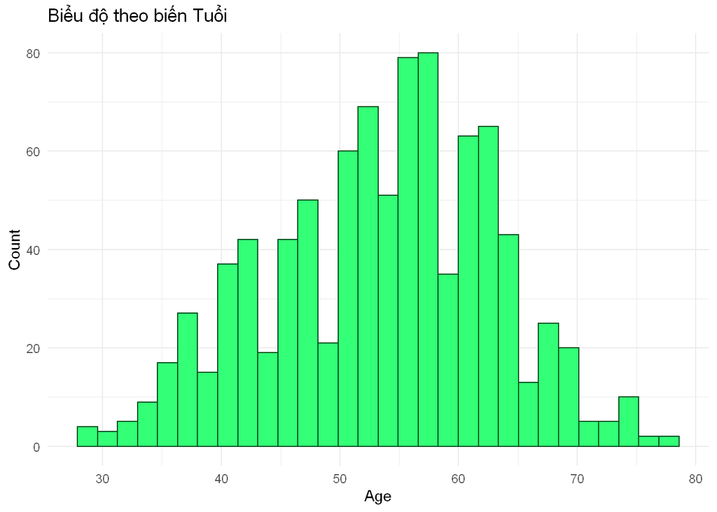

```r
ggplot(data = datadisease, aes(x = Age)) +
  geom_histogram(color = "#004d1a", fill = "#33ff77") +
  labs(title = "Biểu độ theo biến Tuổi", x = "Age", y = "Count") +
  theme_minimal()
```

- Biểu đồ hiện thị theo lượng Cholesterol:

```r
datadisease$Cholesterol %>% summary()
```

```
##    Min. 1st Qu.  Median    Mean 3rd Qu.    Max.
##     0.0   173.2   223.0   198.8   267.0   603.0
```

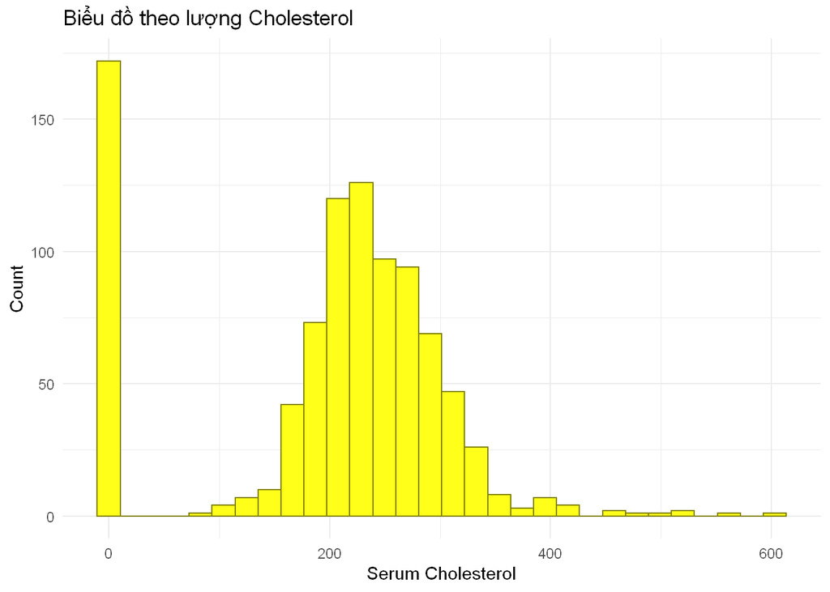

```r
ggplot(data = datadisease, aes(x = Cholesterol)) +
  geom_histogram(color = "#808000", fill = "#ffff1a") +
  labs(title = "Biểu đồ theo lượng Cholesterol", x = "Serum Cholesterol", y = "Count") +
  theme_minimal()
```

- Biểu đồ hiển thị Giới tính nam và nữ tướng ứng F là nữ còn M là nam:

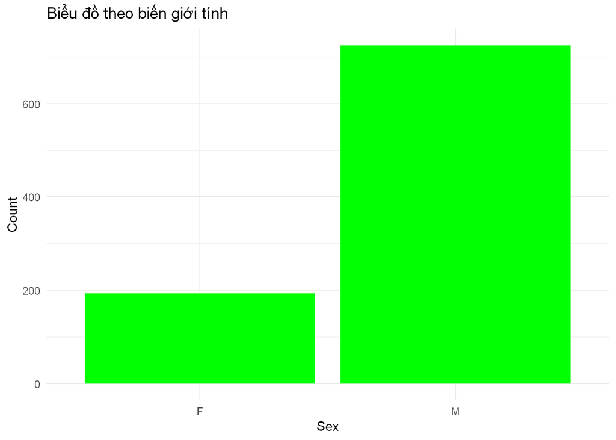

```r
ggplot(data = datadisease, aes(x = Sex)) +
  stat_count(fill = "Green") +
  labs(title = "Biểu đồ theo biến giới tính", x = "Sex", y = "Count") +
  theme_minimal()
```

## Các phương pháp mà nhóm tin rằng sẽ hữu ích trong việc trả lời (các) câu hỏi đặt ra

- Dùng hồi quy tuyến tính để đưa ra dự đoán xem các yếu tố nào sẽ ảnh hưởng nhiều nhất đến bệnh tim.
- Đặt ra các giả thiết có trong dataset và kiểm tra bằng cách trực quan hóa, vẽ biểu đồ để kiểm tra các giả thiết đúng hay sai.

## Kế hoạch thực hiện và phân công việc:

- Trần Tuyên Trường: tìm hiểu ý nghĩa của các biến trong dữ liệu liên quan như thế nào đến bệnh tim. Tìm hiểu lý do ở câu hỏi nghiên cứu thứ hai, nữ giới có khả năng mắc bệnh tim cao hơn nam là do giới tính hay do các biến khác ảnh hưởng tới trong bộ dữ liệu. Tìm hiểu các biểu đồ liên quan để phân tích và đưa ra kết quả.
- Hoàng Uyên: tìm hiểu, nghiên cứu câu hỏi đầu tiên và soạn slide thuyết trình bằng tiếng Anh khi cả nhóm hoàn thành xong. Tìm hiểu và vẽ các biểu đồ để phân tích và đưa ra kết quả chứng minh cho các nhận định nhìn ra.
- Võ Hoàng Nguyên: Tìm hiểu, nghiên cứu câu hỏi thứ ba và soạn slide thuyết trình bằng tiếng Anh khi cả nhóm hoàn thành xong. Tìm hiểu và vẽ các biểu đồ để phân tích và đưa ra kết quả chứng minh cho các nhận định nhìn ra.
- Bùi Tấn Đạt: Tìm hiểu, nghiên cứu câu hỏi cuối cùng và kiểm tra tổng quát các biểu đồ mà nhóm đã vẽ. Tìm hiểu và vẽ các biểu đồ để phân tích và đưa ra kết quả chứng minh cho các nhận định nhìn ra trong câu hỏi cuối cùng.